# W241 Final Project Experiment Results

Jack Workman & Yulia Zamriy

July 29, 2018

## 2. Getting the Data

### 2.1 Load the Data

Survey responses were sourced from three different environments: 1. Amazon Mechanical Turk with Masters qualification 2. Amazon Mechanical Turk without Masters qualification 3. Friends & Family (Facebook, LinkedIn, I School Slack)

Although this step is not critical for analyzing the results of the experiment, it might be interesting to know later on where a subject was recruited from. So, here we pre-process the data to explicitly identify each subject’s group. We do that by matching the mTurkCOde from the Amazon Mechanical Turk (mturk) responses to the mTurkCode in the qualtrics data set.

```r
mturk_masters = read.csv("experiment_results/mturk_W241_Final-Project_Survey_Masters-Batch_Results.csv")
mturk_regulars = read.csv("experiment_results/mturk_W241_Final-Project_Survey_Non-Masters-Batch_Results.csv")

# the second and third rows of the qualtrics results contain meta info we do not need so we remove it here
all_content = readLines("experiment_results/qualtrics_W241_Final-Project_Survey_Experiment_August-1-2018_14-06.csv")
all_content = all_content[-3]
all_content = all_content[-2]
qualtrics = read.csv(textConnection(all_content), header = TRUE, stringsAsFactors = FALSE)
rm(all_content)
# thank you: https://stackoverflow.com/questions/15860071/read-csv-header-on-first-line-skip-second-line
```

### 2.2 Concatenate MTurk Masters & MTurk Regulars

```r
# assign groups
mturk_masters['source_group'] = 1
mturk_regulars['source_group'] = 2
mturk_all = rbind(mturk_masters, mturk_regulars)

# keep these columns and drop the rest (switched to reverse where we explicitly drop the not necessary ones so that we are more clear about what we are dropping)
#mturk_cols_to_keep = c('HITId', 'CreationTime', 'Expiration', 'AssignmentId', 'WorkerId', 'AssignmentStatus', 'AcceptTime', 'SubmitTime', 'WorkTimeInSeconds', 'LifetimeApprovalRate', 'Last30DaysApprovalRate', 'Last7DaysApprovalRate', 'Answer.surveycode', 'source_group')
#mturk_all = mturk_all[mturk_cols_to_keep]

# drop unnecessary columns
mturk_all = subset(mturk_all, select = -c(HITTypeId, Title, Description, Keywords, Reward, MaxAssignments, RequesterAnnotation, AssignmentDurationInSeconds, AutoApprovalDelayInSeconds, NumberOfSimilarHITs, LifetimeInSeconds, AssignmentId, AutoApprovalTime, ApprovalTime, RejectionTime, RequesterFeedback, Approve, Reject))

# rename mTurkCode column to match qualtrics
mturk_all['mTurkCode'] = mturk_all['Answer.surveycode']

# check out the combined dataset
#head(mturk_all)
table(mturk_all['source_group'])
```

```
##
##   1   2
##  42 300
```

```r
dim(mturk_all)
```

```
## [1] 342  14
```

### 2.3 Merge MTurk and Qualtrics Datasets

```r
#head(qualtrics)
responses = merge(x = qualtrics, y = mturk_all, by = "mTurkCode", all.x = TRUE)
str(responses)
```

```
## 'data.frame':    519 obs. of  42 variables:
##  $ mTurkCode             : int  36024 40455 54977 69452 73090 101232 163397 177783 198944 211199 ...
##  $ StartDate             : chr  "2018-07-27 23:46:35" "2018-07-27 23:21:59" "2018-07-27 23:04:15" "2018-07-24 02:56:01" ...
##  $ EndDate               : chr  "2018-07-27 23:50:56" "2018-07-27 23:23:02" "2018-07-27 23:04:57" "2018-07-24 03:02:46" ...
##  $ Status                : chr  "IP Address" "IP Address" "IP Address" "IP Address" ...
##  $ IPAddress             : chr  "171.49.203.64" "173.20.162.249" "157.50.75.22" "122.62.18.119" ...
##  $ Progress              : int  100 100 100 100 100 100 100 100 100 100 ...
##  $ Duration..in.seconds. : int  261 63 42 404 312 660 3508 1231 56 254 ...
##  $ Finished              : chr  "True" "True" "True" "True" ...
##  $ RecordedDate          : chr  "2018-07-27 23:50:57" "2018-07-27 23:23:03" "2018-07-27 23:04:57" "2018-07-24 03:02:47" ...
##  $ ResponseId            : chr  "R_2TXk8sWK36jzkxM" "R_1jJM9C9b2TH7KAH" "R_3O6vnIhnFXNmN55" "R_27WsIoQpdXIygaA" ...
##  $ RecipientLastName     : logi  NA NA NA NA NA NA ...
##  $ RecipientFirstName    : logi  NA NA NA NA NA NA ...
##  $ RecipientEmail        : logi  NA NA NA NA NA NA ...
##  $ ExternalReference     : logi  NA NA NA NA NA NA ...
```

[output cut: 28 more lines]

```r
table(responses$source_group)
```

```
##
##   1   2
##  42 298
```

```r
#head(responses)
#colnames(responses)
responses$source_group[is.na(responses$source_group)] = 3
responses$source_group <- factor(responses$source_group, labels = c("Mturk Masters", "Mturk Regulars", "F&F"))
#hist(responses$source_group, breaks=3) # could probably make this prettier
table(responses$source_group)
```

```
##
##  Mturk Masters Mturk Regulars            F&F
##             42            298            179
```

```r
rm(list = c('mturk_all', 'mturk_masters', 'mturk_regulars', 'qualtrics'))
```

## 3. Data Cleaning

### 3.1 Identifying Invalid Data Rows

Potentially invalid responses are those that:

- have `Status` = ‘Spam’ or ‘Survey Preview’
- Duplicate `IPAddress` occurance. We’ll keep the first response for the analysis (alternatively, we can exclude all of them)
- not finished (progress less than 100%). These cases need to be investigated for potential bias

#### 3.1.1 Invalid Status

```r
table(responses$Status)
```

```
##
##     IP Address           Spam Survey Preview
##            514              1              4
```

#### 3.1.2 Duplicate IP Addresses

```r
# record duplicate IP Addresses and first timestamp
responses %>%
  group_by(IPAddress) %>%
  arrange(StartDate) %>%
  summarize(ip_count = n(),
            StartDate = first(StartDate)) %>%
  filter(ip_count > 1) -> duplicate_ips

# merge duplicate IP Addresses based on first time stamp
responses <- merge(x = responses, y = duplicate_ips,
               by = c("IPAddress", "StartDate"), all.x = TRUE)
# merge all duplicate IP Addresses
responses <- merge(x = responses, y = duplicate_ips[,c("IPAddress", "ip_count")],
               by = "IPAddress", all.x = TRUE)

responses$duplicate_ip <- 0
responses[!is.na(responses$ip_count.y),]$duplicate_ip <- 1
responses$duplicate_ip_xfirst <- 0
responses[!is.na(responses$ip_count.x),]$duplicate_ip_xfirst <- 1
responses$ip_count.x <- NULL
colnames(responses)[colnames(responses)=="ip_count.y"] <- "ip_count"
responses[is.na(responses$ip_count),]$ip_count <- 1
rm(duplicate_ips)
```

```r
table(responses$duplicate_ip, responses$duplicate_ip_xfirst)
```

```
##
##       0   1
##   0 430   0
##   1  60  29
```

```r
table(responses$ip_count)
```

```
##
##   1   2   3   4   5  16
## 430  38   9  16  10  16
```

#### 3.1.3 Unfinished Surveys

We have 70 responses that were not finished. We’ll create a separate flag variable to determine if they are a cause for attrition concern:

```r
cat(separator)
cat("\nSummary of survey's progress:\n")
```

```
##
## Summary of survey's progress:
```

```r
summary(responses$Progress)
```

```
##    Min. 1st Qu.  Median    Mean 3rd Qu.    Max.
##   53.00  100.00  100.00   94.24  100.00  100.00
```

```r
cat(separator)
cat("\nNumber of responses that are not finished:\n")
```

```
##
## Number of responses that are not finished:
```

```r
sum(responses$Progress < 100)
```

```
## [1] 70
```

```r
cat(separator)
cat("\nPrimary outcome distribution for unfinished responses:\n")
```

```
##
## Primary outcome distribution for unfinished responses:
```

```r
table(responses[responses$Progress < 100,]$Q4)
```

```
## < table of extent 0 >
```

```r
cat(separator)
cat("\nSource of  unfinished responses:\n")
```

```
##
## Source of  unfinished responses:
```

```r
table(responses[responses$Progress < 100,]$source_group)
```

```
##
##  Mturk Masters Mturk Regulars            F&F
##              0              0             70
```

```r
cat(separator)
cat("\nTreatment assignment for unfinished responses:\n")
```

```
##
## Treatment assignment for unfinished responses:
```

```r
table(responses[responses$Progress < 100,]$FL_2_DO)
```

```
##
##    Introduction:1Star Introduction:4.5Stars  Introduction:Control
##                    17                    28                    25
```

#### 3.1.4 Putting It All Together

```r
responses$valid <- "Valid"
responses[responses$Status %in% c("Spam", "Survey Preview"), ]$valid <- "Preview/Spam"
responses[responses$duplicate_ip_xfirst==1,]$valid <- "Duplicate"
responses[responses$Progress < 100,]$valid <- "Not Finished"
table(responses$valid)
```

```
##
##    Duplicate Not Finished Preview/Spam        Valid
##           23           70            3          423
```

```r
cat(separator)
cat("\nSource of valid responses:\n")
```

```
##
## Source of valid responses:
```

```r
table(responses[responses$valid == "Valid",]$source_group)
```

```
##
##  Mturk Masters Mturk Regulars            F&F
##             39            291             93
```

```r
cat("\nSource of invalid responses:\n")
```

```
##
## Source of invalid responses:
```

```r
table(responses[responses$valid != "Valid",]$source_group)
```

```
##
##  Mturk Masters Mturk Regulars            F&F
##              3              7             86
```

```r
cat(separator)
cat("\nTreatment assignment for valid responses:\n")
```

```
##
## Treatment assignment for valid responses:
```

```r
table(responses[responses$valid == "Valid",]$FL_2_DO)
```

```
##
##    Introduction:1Star Introduction:4.5Stars  Introduction:Control
##                   135                   141                   147
```

```r
cat("\nTreatment assignment for invalid responses:\n")
```

```
##
## Treatment assignment for invalid responses:
```

```r
table(responses[responses$valid != "Valid",]$FL_2_DO)
```

```
##
##    Introduction:1Star Introduction:4.5Stars  Introduction:Control
##                    27                    38                    31
```

```r
table(responses[responses$valid == "Valid",]$FL_2_DO, responses[responses$valid == "Valid",]$source_group)
```

```
##
##                         Mturk Masters Mturk Regulars F&F
##   Introduction:1Star               10             90  35
##   Introduction:4.5Stars            12            101  28
##   Introduction:Control             17            100  30
```

### 3.2 Are Valid Responses Actually Valid?

```r
short_story_word_count = 990
duration_secs_minimum = 30
correct_answers_minimum = 1
```

This experiment relies entirely on the assumption that the subjects read the short story. To ensure this, we added several validation checks to the survey.

```r
valid_responses = subset(responses, valid == "Valid")
```

```r
summary(valid_responses$Duration..in.seconds.)
```

```
##    Min. 1st Qu.  Median    Mean 3rd Qu.    Max.
##     9.0   104.5   305.0   744.5   494.0 78097.0
```

```r
sum(valid_responses$Duration..in.seconds. < 1200)
```

```
## [1] 400
```

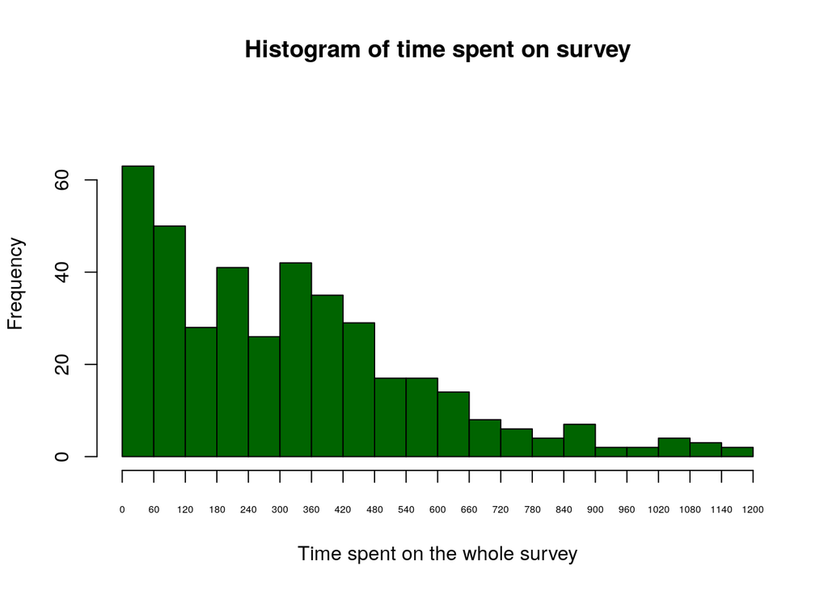

```r
hist(valid_responses[valid_responses$Duration..in.seconds. < 1200,]$Duration..in.seconds.,
     col = "darkgreen",
     breaks = seq(0,1200,60),
     ylim = c(0, 75),
     xaxt = 'n',
     xlab = "Time spent on the whole survey",
     main = "Histogram of time spent on survey")
axis(side = 1, at = seq(0,1200,60), labels = seq(0,1200,60), cex.axis = 0.5)
```

```r
summary(valid_responses$Q2_Page.Submit)
```

```
##     Min.  1st Qu.   Median     Mean  3rd Qu.     Max.
##    1.511    9.493  126.567  204.099  265.954 7691.925
```

```r
sum(valid_responses$Q2_Page.Submit < 600)
```

```
## [1] 403
```

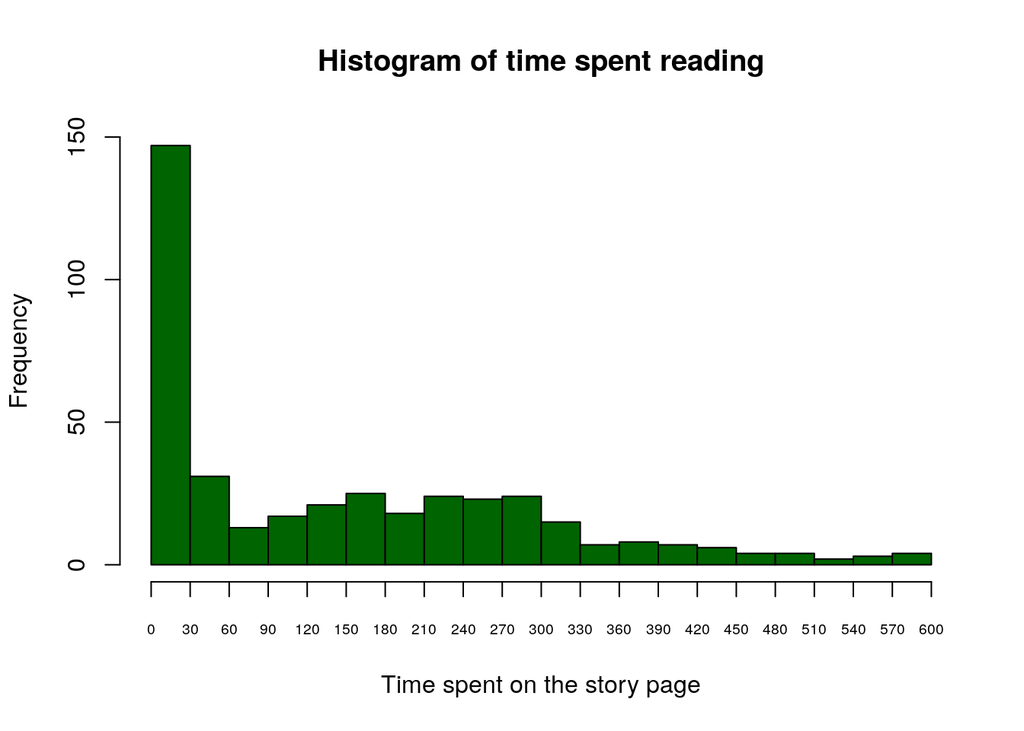

```r
hist(valid_responses[valid_responses$Q2_Page.Submit < 600,]$Q2_Page.Submit,
     col = "darkgreen",
     breaks = seq(0,600,30),
     ylim = c(0, 150),
     xaxt = 'n',
     xlab = "Time spent on the story page",
     main = "Histogram of time spent reading")
axis(side = 1, at = seq(0,600,30), labels = seq(0,600,30), cex.axis = 0.6)
```

```r
# reading time check
#valid_responses = subset(valid_responses, Q2_Page.Submit >= duration_secs_minimum)
valid_responses[valid_responses$Q2_Page.Submit < duration_secs_minimum,]$valid <- "Undertime"
table(valid_responses$valid)
```

```
##
## Undertime     Valid
##       147       276
```

```r
table(valid_responses$valid, valid_responses$FL_2_DO)
```

```
##
##             Introduction:1Star Introduction:4.5Stars Introduction:Control
##   Undertime                 45                    53                   49
##   Valid                     90                    88                   98
```

```r
table(valid_responses$valid, valid_responses$source_group)
```

```
##
##             Mturk Masters Mturk Regulars F&F
##   Undertime             5            128  14
##   Valid                34            163  79
```

```r
# reading questions check
Q12_correct_ans = 'Beautiful'
Q14_correct_ans = 'Rome'
Q16_correct_ans = 'Gaius was killed'
valid_responses['Q12_correct'] = ifelse(valid_responses$Q12 == Q12_correct_ans, 1, 0)
valid_responses['Q14_correct'] = ifelse(valid_responses$Q14 == Q14_correct_ans, 1, 0)
valid_responses['Q16_correct'] = ifelse(valid_responses$Q12 == Q16_correct_ans, 1, 0)
valid_responses['correct_answers'] = valid_responses$Q12_correct + valid_responses$Q14_correct + valid_responses$Q16_correct
table(valid_responses$correct_answers)
```

```
##
##   0   1   2
##  63 121 239
```

```r
valid_responses[valid_responses$correct_answers < correct_answers_minimum,]$valid <- "Very incorrect"
table(valid_responses$valid)
```

```
##
##      Undertime          Valid Very incorrect
##             95            265             63
```

```r
sum(valid_responses$Q4 == -99)
```

```
## [1] 8
```

```r
valid_responses[valid_responses$Q4 == -99,]$valid <- "Missing outcome"
table(valid_responses$valid)
```

```
##
## Missing outcome       Undertime           Valid  Very incorrect
##               8              95             265              55
```

```r
table(valid_responses$Q25)
```

```
##
##     -99  No Yes
##   4   5 292 122
```

```r
valid_responses$issues <- "No issues"
#valid_responses[valid_responses$Q25 == 'Yes',]$issues <- "Know the story"
valid_responses[valid_responses$Q25 == '-99',]$issues <- "Know the story"
valid_responses[valid_responses$Q5 == '-99',]$issues <- "Missing text review"
valid_responses[valid_responses$Q12 == '-99',]$issues <- "Missing answer"
valid_responses[valid_responses$Q14 == '-99',]$issues <- "Missing answer"
valid_responses[valid_responses$Q16 == '-99',]$issues <- "Missing answer"
table(valid_responses$issues)
```

```
##
##      Know the story      Missing answer Missing text review
##                   1                  15                  22
##           No issues
##                 385
```

```r
table(valid_responses$valid, valid_responses$issues)
```

```
##
##                   Know the story Missing answer Missing text review
##   Missing outcome              0              8                   0
##   Undertime                    0              1                   8
##   Valid                        1              0                   8
##   Very incorrect               0              6                   6
##
##                   No issues
##   Missing outcome         0
##   Undertime              86
##   Valid                 256
##   Very incorrect         43
```

```r
nrows_raw <- nrow(responses)
excl_dups_unfinished <- nrow(valid_responses)
excl_dur_undertime <- excl_dups_unfinished - sum(valid_responses$valid == 'Undertime')
excl_incorrect_answ <- excl_dur_undertime - sum(valid_responses$valid == 'Very incorrect')
excl_missing_outcome <- excl_incorrect_answ - sum(valid_responses$valid == 'Missing outcome')
nrows_final <- sum(valid_responses$valid == 'Valid')
```

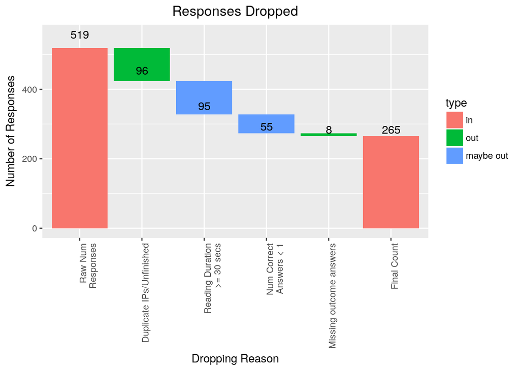

```r
labels = c('Raw Num\nResponses',
           'Duplicate IPs/Unfinished',
           sprintf('Reading Duration\n>= %s secs', duration_secs_minimum),
           sprintf('Num Correct\nAnswers < %s', correct_answers_minimum),
           'Missing outcome answers',
           'Final Count')

desc = factor(labels, levels=labels)
type = c('in', 'out', 'maybe out', 'maybe out', 'out', 'in')
type = factor(type, levels = c("in", "out", "maybe out"))

start = c(0, nrows_raw, excl_dups_unfinished, excl_dur_undertime, excl_incorrect_answ, excl_missing_outcome)
end = c(nrows_raw, excl_dups_unfinished, excl_dur_undertime, excl_incorrect_answ, nrows_final, 0)
amount = c(nrows_raw, -excl_dups_unfinished, -excl_dur_undertime, -excl_incorrect_answ, -excl_missing_outcome, -nrows_final)
id = seq_along(amount)
waterfall_data = data.frame(id, desc, type, start, end, amount)

label_names <- c(nrows_raw,
                 nrows_raw - excl_dups_unfinished,
                 excl_dups_unfinished - excl_dur_undertime,
                 excl_dur_undertime - excl_incorrect_answ,
                 excl_incorrect_answ - excl_missing_outcome,
                 nrows_final)

adj <- 1.075
label_pos <- c(nrows_raw * adj,
               excl_dups_unfinished * adj,
               excl_dur_undertime * adj,
               excl_incorrect_answ * adj,
               excl_missing_outcome * adj,
               nrows_final * adj)

waterfall_plot =
  ggplot(waterfall_data, aes(desc, fill = type,
                             xmin = id - 0.45, xmax = id + 0.45, ymin = end, ymax = start, label = label_names)) +
  geom_rect()
waterfall_plot +
  ggtitle("Responses Dropped") +
  theme(plot.title = element_text(hjust = 0.5),
        axis.text.x = element_text(angle = 90, hjust = 1)) +
  labs(y="Number of Responses", x="Dropping Reason") +
  geom_text(aes(y = label_pos, label = label_names))
```

```r
rm(list = c("adj", "amount", "desc", "end", "id", "label_names", "label_pos", "labels", "start", "type"))
rm(list = c("excl_dups_unfinished", "excl_dur_undertime", "excl_incorrect_answ"))
rm(list = c("excl_missing_outcome", "nrows_final", "nrows_raw"))
rm(list = c("Q12_correct_ans", "Q14_correct_ans", "Q16_correct_ans"))
rm(list = c("correct_answers_minimum", "duration_secs_minimum", "short_story_word_count"))
rm(list = c("waterfall_data", "waterfall_plot"))
```

## Identify Treatment and Control Groups

There are three distinct groups in this experiment:

1. Control
2. Treatment - Low Rating
3. Treatment - High Rating

```r
valid_responses['experiment_group'] = ifelse(valid_responses$FL_2_DO == 'Introduction:Control', 1,
                                       ifelse(valid_responses$FL_2_DO == 'Introduction:1Star', 2,
                                              ifelse(valid_responses$FL_2_DO == 'Introduction:4.5Stars', 3, -1)))
valid_responses['treated'] = ifelse(valid_responses$experiment_group == 2, 1,
                                       ifelse(valid_responses$experiment_group == 3, 1, 0))
valid_responses['treatment_rating'] = ifelse(valid_responses$experiment_group == 2, 2,
                                       ifelse(valid_responses$experiment_group == 3, 5, NA))
valid_responses['experiment_group_chr'] = ifelse(valid_responses$FL_2_DO == 'Introduction:Control', "Control",
                                       ifelse(valid_responses$FL_2_DO == 'Introduction:1Star', "Treat: Low",
                                              ifelse(valid_responses$FL_2_DO == 'Introduction:4.5Stars', "Treat: High", "NA")))
```

```r
table(valid_responses$experiment_group, valid_responses$experiment_group_chr)
```

```
##
##     Control Treat: High Treat: Low
##   1     147           0          0
##   2       0           0        135
##   3       0         141          0
```

```r
summary(valid_responses$Q4)
```

```
##    Min. 1st Qu.  Median    Mean 3rd Qu.    Max.
## -99.000   3.000   4.000   2.135   5.000   6.000
```

```r
summary(valid_responses[valid_responses$valid == "Valid",]$Q4)
```

```
##    Min. 1st Qu.  Median    Mean 3rd Qu.    Max.
##   1.000   3.000   4.000   4.125   5.000   6.000
```

```r
valid_responses %>%
  filter(valid != "Missing outcome") %>%
  group_by(valid, FL_2_DO) %>%
  summarize(responseCount = n(),
            avgRating = round(mean(Q4),1))
```

```
## # A tibble: 9 x 4
## # Groups:   valid [?]
##   valid          FL_2_DO               responseCount avgRating
##   <chr>          <chr>                         <int>     <dbl>
## 1 Undertime      Introduction:1Star               33       4.5
## 2 Undertime      Introduction:4.5Stars            33       4.4
## 3 Undertime      Introduction:Control             29       3.8
## 4 Valid          Introduction:1Star               86       3.7
## 5 Valid          Introduction:4.5Stars            84       4.3
## 6 Valid          Introduction:Control             95       4.4
## 7 Very incorrect Introduction:1Star               12       2.9
## 8 Very incorrect Introduction:4.5Stars            22       3.7
## 9 Very incorrect Introduction:Control             21       4
```

## Calculate ATE

```r
calc_exp_group_avg_rating = function(data, group) {
  avg_rating = mean(subset(data, experiment_group == group)$Q4)
  return(avg_rating)
}
get_nrow_of_group = function(data, group) {
  rows = nrow(subset(data, experiment_group == group))
  return(rows)
}
get_pct_subjects_of_group = function(data, group) {
  count = get_nrow_of_group(data, group)
  pct = round(count / nrow(data) * 100, 2)
  return(pct)
}
control_avg_rating = calc_exp_group_avg_rating(valid_responses[valid_responses$valid == "Valid",], 1)
treatment_low_avg_rating = calc_exp_group_avg_rating(valid_responses[valid_responses$valid == "Valid",], 2)
treatment_high_avg_rating = calc_exp_group_avg_rating(valid_responses[valid_responses$valid == "Valid",], 3)
# todo: is this actually how you calculate ATE?
ate_high = treatment_high_avg_rating - control_avg_rating
ate_low = treatment_low_avg_rating - control_avg_rating
groups = c(
  'Control',
  'Treatment - Low Rating',
  'Treatment - High Rating')
counts = c(
  get_nrow_of_group(valid_responses[valid_responses$valid == "Valid",], 1),
  get_nrow_of_group(valid_responses[valid_responses$valid == "Valid",], 2),
  get_nrow_of_group(valid_responses[valid_responses$valid == "Valid",], 3))
pcts = c(
  get_pct_subjects_of_group(valid_responses[valid_responses$valid == "Valid",], 1),
  get_pct_subjects_of_group(valid_responses[valid_responses$valid == "Valid",], 2),
  get_pct_subjects_of_group(valid_responses[valid_responses$valid == "Valid",], 3))
avg_ratings = c(
  round(control_avg_rating,2),
  round(treatment_low_avg_rating,2),
  round(treatment_high_avg_rating,2))
ates = c(
  0,
  round(ate_low,2),
  round(ate_high,2))
treated_ratings = c('na', '2/6 Stars', '5/6 Stars')
outcome_table = data.frame(groups, counts, pcts, treated_ratings, avg_ratings, ates)
kable(outcome_table, col.names = c('Group', '# of Subjects', '% of Total Subjects', 'Treated Rating', 'AVG Rating', 'ATE'))
```

| Group | # of Subjects | % of Total Subjects | Treated Rating | AVG Rating | ATE |
| --- | --- | --- | --- | --- | --- |
| Control | 95 | 35.85 | na | 4.38 | 0.00 |
| Treatment - Low Rating | 86 | 32.45 | 2/6 Stars | 3.71 | -0.67 |
| Treatment - High Rating | 84 | 31.70 | 5/6 Stars | 4.26 | -0.12 |

## Model

```r
model = lm(Q4 ~ factor(experiment_group_chr), data = valid_responses[valid_responses$valid == "Valid",])
summary(model)
```

```
##
## Call:
## lm(formula = Q4 ~ factor(experiment_group_chr), data = valid_responses[valid_responses$valid ==
##     "Valid", ])
##
## Residuals:
##     Min      1Q  Median      3Q     Max
## -3.2619 -0.7093  0.2907  0.7381  2.2907
##
## Coefficients:
##                                         Estimate Std. Error t value
## (Intercept)                               4.3789     0.1042  42.018
## factor(experiment_group_chr)Treat: High  -0.1170     0.1521  -0.769
## factor(experiment_group_chr)Treat: Low   -0.6696     0.1512  -4.429
##                                         Pr(>|t|)
## (Intercept)                              < 2e-16 ***
## factor(experiment_group_chr)Treat: High    0.442
## factor(experiment_group_chr)Treat: Low  1.39e-05 ***
## ---
## Signif. codes:  0 '***' 0.001 '**' 0.01 '*' 0.05 '.' 0.1 ' ' 1
##
## Residual standard error: 1.016 on 262 degrees of freedom
## Multiple R-squared:  0.07703,    Adjusted R-squared:  0.06999
## F-statistic: 10.93 on 2 and 262 DF,  p-value: 2.751e-05
```

```r
coefci(model)
```

```
##                                              2.5 %     97.5 %
## (Intercept)                              4.1737403  4.5841545
## factor(experiment_group_chr)Treat: High -0.4165995  0.1825143
## factor(experiment_group_chr)Treat: Low  -0.9673475 -0.3719426
```

```r
valid_responses$undertime <- ifelse(valid_responses$valid == "Undertime", 1, 0)
valid_responses$incorrect <- ifelse(valid_responses$valid == "Very incorrect", 1, 0)
```

```r
model = lm(Q4 ~ factor(experiment_group_chr) + undertime + incorrect,
           data = valid_responses[valid_responses$valid != "Missing outcome",])
summary(model)
```

```
##
## Call:
## lm(formula = Q4 ~ factor(experiment_group_chr) + undertime +
##     incorrect, data = valid_responses[valid_responses$valid !=
##     "Missing outcome", ])
##
## Residuals:
##     Min      1Q  Median      3Q     Max
## -3.3698 -0.8515  0.1485  0.7463  2.2776
##
## Coefficients:
##                                          Estimate Std. Error t value
## (Intercept)                              4.253724   0.098899  43.011
## factor(experiment_group_chr)Treat: High  0.004239   0.130159   0.033
## factor(experiment_group_chr)Treat: Low  -0.402244   0.132407  -3.038
## undertime                                0.116109   0.131130   0.885
## incorrect                               -0.531294   0.162830  -3.263
##                                         Pr(>|t|)
## (Intercept)                              < 2e-16 ***
## factor(experiment_group_chr)Treat: High  0.97404
## factor(experiment_group_chr)Treat: Low   0.00253 **
## undertime                                0.37643
## incorrect                                0.00120 **
## ---
## Signif. codes:  0 '***' 0.001 '**' 0.01 '*' 0.05 '.' 0.1 ' ' 1
##
## Residual standard error: 1.095 on 410 degrees of freedom
## Multiple R-squared:  0.05399,    Adjusted R-squared:  0.04476
## F-statistic:  5.85 on 4 and 410 DF,  p-value: 0.0001381
```

```r
coefci(model)
```

```
##                                              2.5 %     97.5 %
## (Intercept)                              4.0593120  4.4481364
## factor(experiment_group_chr)Treat: High -0.2516234  0.2601012
## factor(experiment_group_chr)Treat: Low  -0.6625253 -0.1419624
## undertime                               -0.1416626  0.3738808
## incorrect                               -0.8513802 -0.2112074
```